# Application of Bootstrap Resampling on Student Mental Health Data

## Exploratory Data Analysis

As with any Data Science project, especially ones where bootstrapping ins involved, some EDA is required to analyze certain relationships among variables.

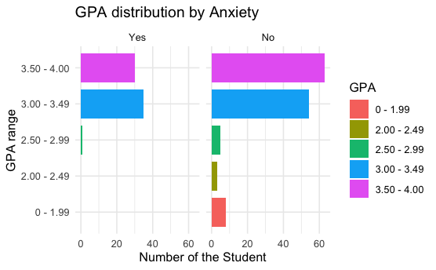

The graph shows that the majority of students have GPA between 3.00 and 4.00. Students who respond that they suffer from anxiety do not have a low gap. As a result, we can infer that there isn’t much of a connection between anxiety and a high or low GPA.

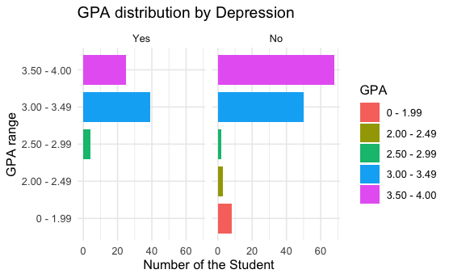

Students who reported having depression also revealed the same result. These GPA-high students experience depression as well. We can suggest that there is also no strong relationship between depression and GPAs. Other elements, such as interactions with family or friends, the stress of maintaining a student budget and living expenses, and the pressure of looking for internships and jobs, can contribute to depression and anxiety.

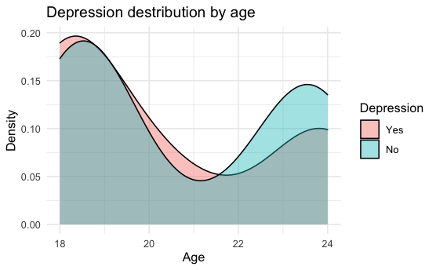

[figure not shown]

Two graphs above show density distribution by age for anxiety and depression. Graphs capture the same pattern as a U shape, and the number of people aged 18 and 24 indicating anxiety and depression are the most. There is a observation that could account for this phenomenon. Freshmen may feel uneasy in their new environment because they are unfamiliar with university policies and programs.

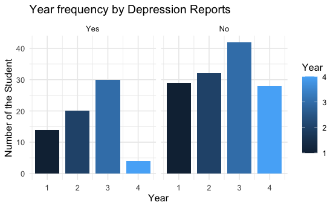

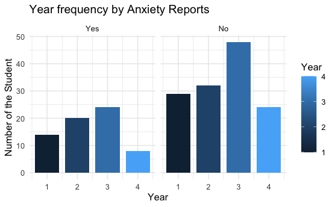

School year frequency also shows the same rule for depression and anxiety. The number of students replying to have depression and anxiety increases from year one and raise to peaks in year three. Finding a full-time job and applying to graduate programs may put pressure on junior students. This may explain why junior students have the largest group of students having depression or anxiety.

Below is the correlation plot between each variable

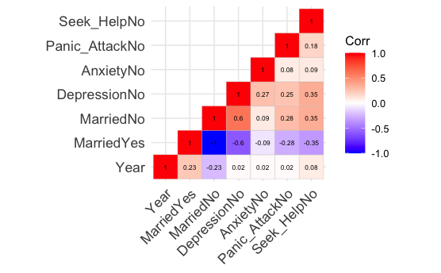

## Example of our Model

Before we bootstrap across 1000 different samples, it might be cool to see how our model works. Take Group 9 Member Luke for example. He is a 21 year old male, fourth year, statistics major with a GPA ranging from 3.50-4.00. Along with the rest of the predictors, does our model predict that he is depressed?

[figure not shown]

```r
set.seed(27)
luke_info <- c("Male", 21, "Statistics", 4, "3.50 - 4.00", "No", "No", "Yes", "Yes", "No")

student_mh_w_luke <- rbind(student_mh, luke_info)

dep_split <- initial_split(student_mh_w_luke, prop = 0.7, strata = Depression)
  dep_train <- training(dep_split)
  dep_test <- testing(dep_split)

dep_recipe <- recipe(Depression ~ ., dep_train) %>%
  step_rm(Major) %>%
  step_rm(Anxiety) %>%
  step_dummy(all_nominal_predictors())

log_reg <- logistic_reg() %>%
    set_engine("glm") %>%
    set_mode("classification")

dep_wf <- workflow() %>%
  add_model(log_reg) %>%
  add_recipe(dep_recipe)

fit <- fit(dep_wf, dep_train)
pred_dep <- predict(fit, new_data = dep_test, type = "class") %>%
  bind_cols(dep_test) %>%
  rename(Pred_Dep = .pred_class)
pred_dep %>%
  tail(n = 1)
```

```
## # A tibble: 1 × 11
##   Pred_…¹ Gender Age   Major Year  GPA   Married Depre…² Anxiety Panic…³ Seek_…⁴
##   <fct>   <chr>  <chr> <chr> <chr> <chr> <fct>   <fct>   <fct>   <fct>   <fct>
## 1 No      Male   21    Stat… 4     3.50… No      No      Yes     Yes     No
## # … with abbreviated variable names ¹Pred_Dep, ²Depression, ³Panic_Attack,
## #   ⁴Seek_Help
```

No, it predicts that he is not depressed! Maybe our model has some sort of hidden image recognition because of that smile! All jokes aside, this is just one student with one set of information, and our model obviously needs a lot more if the bootstrap is going to work to the desired effect.